# Código de análisis de datos para artículo sobre jóvenes de Centroamerica - Base A

Martín Venegas y Emilia Barrientos

12/11/2021

En este documento se presenta el análisis para el artículo “Evaluación de (in)justicia distributiva en jóvenes de Centroamérica” a cargo del investigador principal Juan Diego García. Específicamente, en este documento de utiliza la Base de Datos A, la cual contiene los datos que se reportarán en el artículo final.

El documento se divide en tres secciones, En la primera sección se cargan las librerías para ejecutar el código. En la segunda sección se cargan los datos a analizar. En la tercera sección se procede al análisis de datos. En la sección de análisis de datos se elaboran tablas descriptivas de los datos, tanto de la muestra total como por cada país. Enseguida, se procede a probar la normalidad de la muestra. En último lugar, se elaboran modelos de regresión *backward stepwise* tanto a nivel general como por cada país.

```r
# 0. Identificación -------------------------------------------------------

#Título: Código de análisis de datos para artículo sobre jóvenes de Centroamérica
#Institución: Centro de Estudios de Conflicto y Cohesión Social (COES)

#Desactivar notación científica
options(scipen=999)
```

```r
# 1. Cargar librerías -----------------------------------------------------

library(pacman)
pacman::p_load(tidyverse,
               sjmisc,
               sjPlot, #Para realizar tablas
               stats, # Test de Kruskal-Wallis
               ggplot2, #Para realizar gráficos
               rstatix, #Revisar normalidad
               lattice,
               olsrr,
               nortest, #test Lilliefors
               MASS,
               summarytools,
               VIM,
               table1,
               car,
               jtools,
               ggstance,
               broom.mixed,
               huxtable,
               officer,
               flextable,
               FSA,
               openxlsx)
```

[output not shown]

[output not shown]

[output not shown]

[output not shown]

[output not shown]

[output not shown]

[output not shown]

[output not shown]

[output not shown]

[output not shown]

```r
# 2. Cargar datos procesados ----------------------------------------------

datos_proc_a <- readRDS("../input/data/datos_proc_a.rds")
costa_rica_a <- readRDS("../input/data/costa_rica_a.rds")
nicaragua_a <- readRDS("../input/data/nicaragua_a.rds")
el_salvador_a <- readRDS("../input/data/el_salvador_a.rds")
guatemala_a <- readRDS("../input/data/guatemala_a.rds")
honduras_a <- readRDS("../input/data/honduras_a.rds")
```

```r
# 3. Análisis de datos ----------------------------------------------------
```

```r
# 3.0 Tabla general, tabla general por países y análisis NA-------------------------------------------------------

# General
df_gen2_a<- dfSummary(datos_proc_a,
               plain.ascii = FALSE,
               style = "grid",
               tmp.img.dir = "/tmp",
               graph.magnif = TRUE,
               headings = F,  # encabezado
               varnumbers = F, # num variable
               labels.col = T, # etiquetas
               na.col = T,    # missing
               graph.col = T, # plot
               valid.col = T, # n valido
               col.widths = c(10,1000,10,10,10,10,10)
               )
```

```
## temporary images written to 'C:\tmp'
```

```r
# df_gen2_a$Variable <- NULL # delete variable column
summarytools::view(df_gen2_a, file = "../output/tables/df_gen2_a.html") # Ver tabla en un archivo HTML
```

```
## Output file written: C:\Work\art_centroam\output\tables\df_gen2_a.html
```

```r
# Costa rica

df_costa_rica<- dfSummary(costa_rica_a,
               plain.ascii = FALSE,
               style = "grid",
               tmp.img.dir = "/tmp",
               graph.magnif = TRUE,
               headings = F,  # encabezado
               varnumbers = F, # num variable
               labels.col = T, # etiquetas
               na.col = T,    # missing
               graph.col = T, # plot
               valid.col = T, # n valido
               col.widths = c(1000,10,10,10,10,10)
               )
```

```
## temporary images written to 'C:\tmp'
```

```r
df_costa_rica$Variable <- NULL # delete variable column
summarytools::view(df_costa_rica, file = "../output/tables/df_costa_rica_a.html") # Ver tabla en un archivo HTML
```

```
## Output file written: C:\Work\art_centroam\output\tables\df_costa_rica_a.html
```

```r
# El Salvador

df_el_salvador<- dfSummary(el_salvador_a,
               plain.ascii = FALSE,
               style = "grid",
               tmp.img.dir = "/tmp",
               graph.magnif = TRUE,
               headings = F,  # encabezado
               varnumbers = F, # num variable
               labels.col = T, # etiquetas
               na.col = T,    # missing
               graph.col = T, # plot
               valid.col = T, # n valido
               col.widths = c(1000,10,10,10,10,10)
               )
```

```
## temporary images written to 'C:\tmp'
```

```r
df_el_salvador$Variable <- NULL # delete variable column
summarytools::view(df_el_salvador, file = "../output/tables/df_el_salvador_a.html") # Ver tabla en un archivo HTML
```

```
## Output file written: C:\Work\art_centroam\output\tables\df_el_salvador_a.html
```

```r
# Guatemala

df_guatemala<- dfSummary(guatemala_a,
               plain.ascii = FALSE,
               style = "grid",
               tmp.img.dir = "/tmp",
               graph.magnif = TRUE,
               headings = F,  # encabezado
               varnumbers = F, # num variable
               labels.col = T, # etiquetas
               na.col = T,    # missing
               graph.col = T, # plot
               valid.col = T, # n valido
               col.widths = c(1000,10,10,10,10,10)
               )
```

```
## temporary images written to 'C:\tmp'
```

```r
df_guatemala$Variable <- NULL # delete variable column
summarytools::view(df_guatemala, file = "../output/tables/df_guatemala_a.html") # Ver tabla en un archivo HTML
```

```
## Output file written: C:\Work\art_centroam\output\tables\df_guatemala_a.html
```

```r
# Honduras

df_honduras<- dfSummary(honduras_a,
               plain.ascii = FALSE,
               style = "grid",
               tmp.img.dir = "/tmp",
               graph.magnif = TRUE,
               headings = F,  # encabezado
               varnumbers = F, # num variable
               labels.col = T, # etiquetas
               na.col = T,    # missing
               graph.col = T, # plot
               valid.col = T, # n valido
               col.widths = c(1000,10,10,10,10,10)
               )
```

```
## temporary images written to 'C:\tmp'
```

```r
df_honduras$Variable <- NULL # delete variable column
summarytools::view(df_honduras, file = "../output/tables/df_honduras_a.html") # Ver tabla en un archivo HTML
```

```
## Output file written: C:\Work\art_centroam\output\tables\df_honduras_a.html
```

```r
# Nicaragua

df_nicaragua<- dfSummary(nicaragua_a,
               plain.ascii = FALSE,
               style = "grid",
               tmp.img.dir = "/tmp",
               graph.magnif = TRUE,
               headings = F,  # encabezado
               varnumbers = F, # num variable
               labels.col = T, # etiquetas
               na.col = T,    # missing
               graph.col = T, # plot
               valid.col = T, # n valido
               col.widths = c(1000,10,10,10,10,10)
               )
```

```
## temporary images written to 'C:\tmp'
```

```r
df_nicaragua$Variable <- NULL # delete variable column
summarytools::view(df_nicaragua, file = "../output/tables/df_nicaragua_a.html") # Ver tabla en un archivo HTML
```

```
## Output file written: C:\Work\art_centroam\output\tables\df_nicaragua_a.html
```

```r
# 3. 1. Tabla de distribución de frecuencias ------------------------------

#Crear dataframe

df1 <- datos_proc_a %>% #A partir de datos procesados
    dplyr::select(pais, distribucion_de_riqueza) %>% #Con las variables de interés
    na.omit(.) %>% #Omitiendo NA
    group_by(pais) %>% # Agrupo por país
    summarise(N = n(), #N por país
              Media = round(mean(distribucion_de_riqueza), 3), #La media redondeada de la variable dependiente por país
              DE = round(sd(distribucion_de_riqueza), 3))# La desviación estándar redondeada de la variable dependiente por país

# Descending order

df1 <- df1[order(-df1$Media),]

# Mostrar tabla
sjPlot::tab_df(df1, #A partir del dataframe creado previamente
               title = "Tabla 1. Evaluación de justicia en la distribución de riquezas", #Título
               encoding = "Latin-1",
               footnote = "Se presenta el tamaño de muestra (N), la media (Media) y la desviación estándar (DE) de la variable dependiente para cada uno de los cinco países de Centroamerica. Una mayor media implica que se evalúa más justicia de parte de los encuestados")
```

Tabla 1. Evaluación de justicia en la distribución de riquezas

| pais | N | Media | DE |
| --- | --- | --- | --- |
| Nicaragua | 279 | 2.34 | 1.30 |
| Costa Rica | 298 | 2.21 | 1.24 |
| Honduras | 297 | 1.98 | 1.29 |
| Guatemala | 296 | 1.71 | 1.12 |
| Salvador | 298 | 1.52 | 0.82 |

Como se puede apreciar en la Tabla 1, el país que presenta una mayor media respecto a las evaluaciones de justicia de los jovenes es Nicaragua (2.34). Es decir, comparando con otros paises de Centroamerica de la muestra, en Nicaragua es donde se evalúa mayor justicia de parte de los jovenes de colonias marginales. En orden decreciente le sigue Costa Rica (2.21), Honduras (1.98), Guatemala (1.71) y por último El Salvador (1.52), siendo el país donde se evalúa menos justicia.

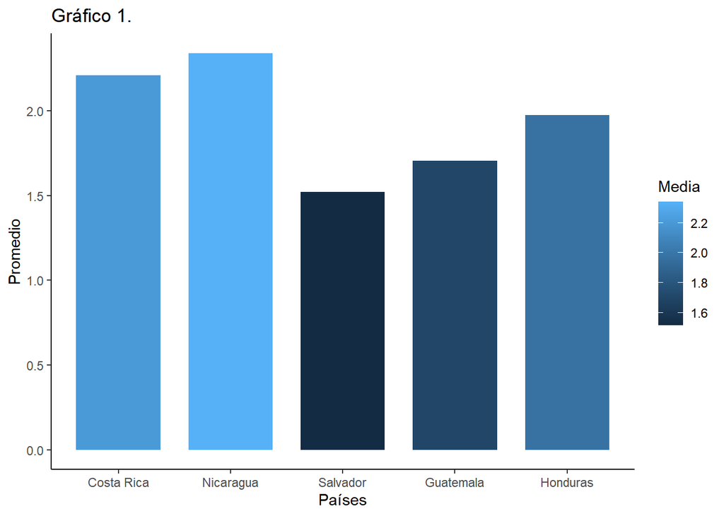

```r
# 3. 2. Gráfico de distribución de frecuencias ----------------------------

# 3. 2. 1. Gráfico del promedio de la variable dependiente para cada país ----

barras <- df1 %>%
  ggplot(df1, #Definir valores por graficar
         mapping = aes(x = pais, #Eje X
             y = Media, #Eje Y
             fill = Media)) + #Color de las barras
  geom_bar(stat = "identity", #Definir el eje Y como valor numérico
           width = 0.75) + #Definir ancho de las barras
  labs(title="Gráfico 1.", #Título
       x="Países",#Etiqueta eje X
       y = "Promedio")+ #Etiqueta eje Y
  theme_classic()

barras
```

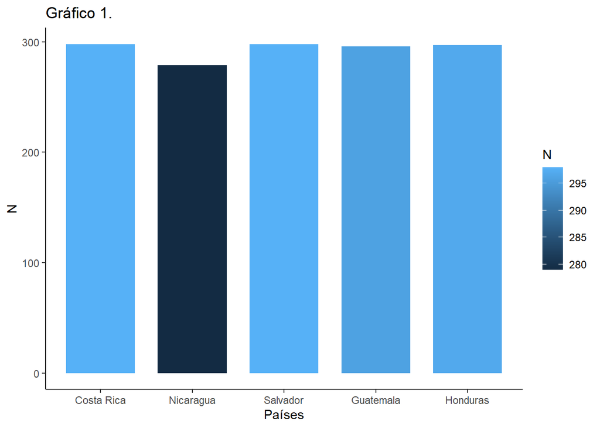

```r
# ggsave(barras, file = "output/tables/barras.pdf", scale=2)

# 3. 2. 2. Gráfico de la frecuencia de respuestas por cada país ----------------

barras2 <- df1 %>%
  ggplot(df1, #Definir valores por graficar
         mapping = aes(x = pais, #Eje X
                       y = N, #Eje Y
                       fill = N)) + #Color de las barras
  geom_bar(stat = "identity", #Definir el eje Y como valor numérico
           width = 0.75) + #Definir ancho de las barras
  labs(title="Gráfico 1.", #Título
       x="Países",#Etiqueta eje X
       y = "N")+ #Etiqueta eje Y
  theme_classic()

barras2
```

```r
# ggsave(barras2, file = "output/tables/barras2.pdf", scale=2)
```

```r
# 3. 3. Revisar la normalidad ---------------------------------------------

# Test de Shapiro-Wilk ----------------------------------------------------

#La hipótesis nula (H0) que la población está distribuida normalmente.
#Si el p-valor es menor a alfa (nivel de significancia), entonces la hipótesis
#nula es rechazada y se concluye que los datos no vienen de una distribución normal).

#En este caso, la hipótesis nula es rechazada, por lo que se concluye que los
#datos no se distribuyen normalmente.

norm_por_pais <- datos_proc_a %>%
  dplyr::select(pais, distribucion_de_riqueza) %>% #Con las variables de interés
  na.omit(.) %>% #Omitiendo NA
  group_by(pais) %>%
  rstatix::shapiro_test(distribucion_de_riqueza)

norm <- datos_proc_a %>%
  rstatix::shapiro_test(distribucion_de_riqueza)

norm_por_pais
```

| pais | variable | statistic | p |
| --- | --- | --- | --- |
| Costa Rica | distribucion_de_riqueza | 0.836 | 4.34e-17 |
| Nicaragua | distribucion_de_riqueza | 0.842 | 3.54e-16 |
| Salvador | distribucion_de_riqueza | 0.67 | 1.06e-23 |
| Guatemala | distribucion_de_riqueza | 0.669 | 1.17e-23 |
| Honduras | distribucion_de_riqueza | 0.747 | 5.08e-21 |

```r
norm
```

| variable | statistic | p |
| --- | --- | --- |
| distribucion_de_riqueza | 0.764 | 1.35e-41 |

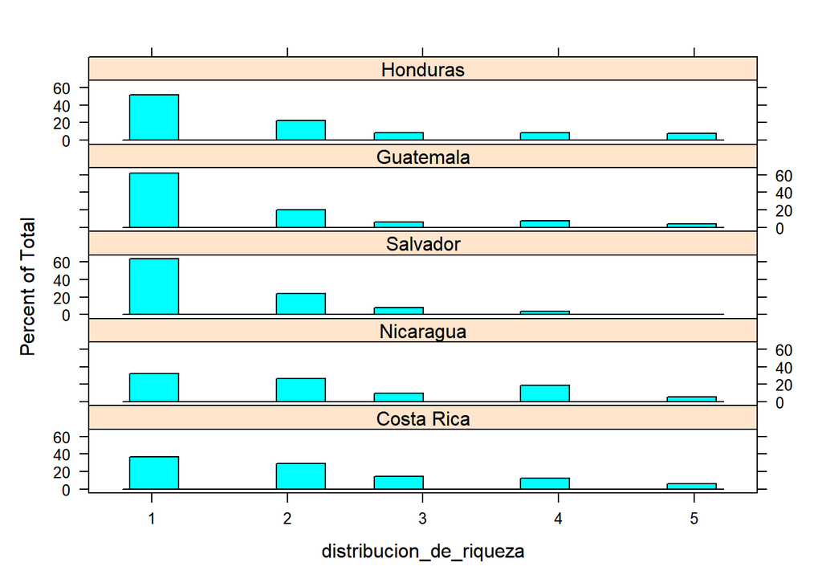

```r
lattice::histogram(~distribucion_de_riqueza|pais,
                   data = datos_proc_a,
                   layout = c(1,5))
```

Se aplica el test de Shapiro Wilk para determinar si los datos provienen de una distribución normal. Se aplica el test a nivel de toda la muestra así como también por país. Los resultados muestran que los datos, tanto a nivel general como por país, no se distribuyen normalmente.

```r
# 3. 4. Comparación de medias ---------------------------------------------

car::leveneTest(distribucion_de_riqueza ~ pais, data = datos_proc_a, center = "median")
```

| Df | F value | Pr(>F) |
| --- | --- | --- |
| 4 | 14 | 3.18e-11 |
| 1463 |  |  |

```r
# Test de Kruskal Wallis --------------------------------------------------

 datos_proc_a %>%
  rstatix::kruskal_test(distribucion_de_riqueza~pais)
```

| .y. | n | statistic | df | p | method |
| --- | --- | --- | --- | --- | --- |
| distribucion_de_riqueza | 1501 | 101 | 4 | 5.45e-21 | Kruskal-Wallis |

```r
# Comparaciones Post - Hoc: Dunn 1964 test -------------------------------------------------

comp_post <- dunnTest(distribucion_de_riqueza ~ pais,
              data=datos_proc_a,
              method="bh")
```

```r
comp_post_data <- comp_post$res

comp_post_data$P.unadj <- ifelse(comp_post_data$P.unadj < 0.001, "<.001",
                                 ifelse(comp_post_data$P.unadj < 0.01, "<.01",
                                        ifelse(comp_post_data$P.unadj < 0.05, "<.05", round(comp_post_data$P.unadj, digits = 2))
                                        )
                                 )

comp_post_data$P.adj <- ifelse(comp_post_data$P.adj < 0.001, "<.001",
                                 ifelse(comp_post_data$P.adj < 0.01, "<.01",
                                        ifelse(comp_post_data$P.adj < 0.05, "<.05", round(comp_post_data$P.adj, digits = 2))
                                        )
                                 )

comp_post_data <- comp_post_data %>% rename("Comparación" = Comparison, "Valor p no ajustado" = P.unadj, "Valor p ajustado" = P.adj)

sjPlot::tab_df(comp_post_data, #A partir del dataframe creado previamente
               title = "Tabla 2. Comparaciones Post Hoc a través de prueba de Dunn con corrección de Benjamini-Hochberg.", #Título
               encoding = "Latin-1",
               footnote = "")
```

Tabla 2. Comparaciones Post Hoc a través de prueba de Dunn con corrección de Benjamini-Hochberg.

| Comparación | Z | Valor.p.no.ajustado | Valor.p.ajustado |
| --- | --- | --- | --- |
| Costa Rica - Guatemala | 5.98 | <.001 | <.001 |
| Costa Rica - Honduras | 3.19 | <.01 | <.01 |
| Guatemala - Honduras | -2.79 | <.01 | <.01 |
| Costa Rica - Nicaragua | -1.01 | 0.31 | 0.31 |
| Guatemala - Nicaragua | -6.89 | <.001 | <.001 |
| Honduras - Nicaragua | -4.15 | <.001 | <.001 |
| Costa Rica - Salvador | 7.19 | <.001 | <.001 |
| Guatemala - Salvador | 1.20 | 0.23 | 0.26 |
| Honduras - Salvador | 3.99 | <.001 | <.001 |
| Nicaragua - Salvador | 8.08 | <.001 | <.001 |

```r
write.xlsx(comp_post_data, file = "../output/tables/comp_post_data.xlsx")
```

```r
# 3. 5. Regresión lineal stepwise backwards -------------------------------

# 3. 5. 1. Modelo general (toda la muestra) -----------------------------------------------

general_reg <- na.omit(datos_proc_a) # hacer una base sin NA para las regresiones

intercept_only_general <- lm(distribucion_de_riqueza ~ 1, data = general_reg) # crear base solo con interceptio

all_general<- lm(distribucion_de_riqueza ~., data = general_reg) # crear modelo de regresión con todos los predictores para hacer backward

# NOTA: Quitando horas_trabajo el modelo funciona. Queda con un n de 105. Quitando seguro_social queda con un n de 226. OJO: esas variables las excluí en el script de procesamiento, pero aquí igual apliqué un na-omit para las otras variables que contenían NA.

stargazer::stargazer(all_general, type = "text") # mostrar tabla para modelo con todos los predictores
```

```
##
## ==================================================================
##                                            Dependent variable:
##                                        ---------------------------
##                                          distribucion_de_riqueza
## ------------------------------------------------------------------
## paisNicaragua                                     0.143
##                                                  (0.112)
##
## paisSalvador                                    -0.573***
##                                                  (0.116)
##
## paisGuatemala                                   -0.408***
##                                                  (0.112)
##
## paisHonduras                                     -0.082
##                                                  (0.110)
##
## sexoHombre                                       -0.001
##                                                  (0.067)
##
## edad                                            -0.032***
##                                                  (0.012)
##
## trabajo_remuneradoSí                              0.073
##                                                  (0.086)
##
## personas_casa                                    0.016*
##                                                  (0.009)
##
## nivel_educPrimaria incompleta                     0.095
##                                                  (0.252)
##
## nivel_educPrimaria completa                       0.351
##                                                  (0.256)
##
## nivel_educSecundaria incompleta                   0.070
##                                                  (0.232)
##
## nivel_educSecundaria completa                    -0.020
```

[output cut: 136 more lines]

```
##
## ind_aut                                          -0.006
##                                                  (0.044)
##
## Constant                                        1.839***
##                                                  (0.469)
##
## ------------------------------------------------------------------
## Observations                                      1,097
## R2                                                0.200
## Adjusted R2                                       0.156
## Residual Std. Error                         1.060 (df = 1039)
## F Statistic                             4.567*** (df = 57; 1039)
## ==================================================================
## Note:                                  *p<0.1; **p<0.05; ***p<0.01
```

```r
# Elaborar modelos por backard step
backward_general<- step(all_general, direction = "backward") # crear moidelo
```

```
## Start:  AIC=183.71
## distribucion_de_riqueza ~ pais + sexo + edad + trabajo_remunerado +
##     personas_casa + nivel_educ + dinero_comida + dinero_casa +
##     dinero_buses + victimas_violencia + org_ddhh + org_medio_amb +
##     org_religion + org_dd_sexuales + org_prev_drogas + org_empleo +
##     org_microcredito + cr_org_adultos_estudio + cr_org_gobs +
##     cr_org_iglesias + cr_org_pers_ud + cr_org_partidos + val_org_resuelvan +
##     val_org_escuchan + val_org_comuniquen + val_org_recolecten +
##     val_org_consejos + val_org_lideres + ind_perc_pas + ind_perc_fut +
##     ind_perc + ind_conf_inst + ind_aut
##
##
## Step:  AIC=183.71
## distribucion_de_riqueza ~ pais + sexo + edad + trabajo_remunerado +
##     personas_casa + nivel_educ + dinero_comida + dinero_casa +
##     dinero_buses + victimas_violencia + org_ddhh + org_religion +
##     org_dd_sexuales + org_prev_drogas + org_empleo + org_microcredito +
##     cr_org_adultos_estudio + cr_org_gobs + cr_org_iglesias +
##     cr_org_pers_ud + cr_org_partidos + val_org_resuelvan + val_org_escuchan +
##     val_org_comuniquen + val_org_recolecten + val_org_consejos +
##     val_org_lideres + ind_perc_pas + ind_perc_fut + ind_perc +
##     ind_conf_inst + ind_aut
##
##                          Df Sum of Sq    RSS    AIC
## - nivel_educ              9    12.016 1178.8 176.94
## - dinero_casa             5     7.195 1174.0 180.45
## - org_microcredito        1     0.000 1166.8 181.71
## - sexo                    1     0.000 1166.8 181.71
## - ind_aut                 1     0.022 1166.9 181.73
## - val_org_comuniquen      1     0.024 1166.9 181.73
## - val_org_resuelvan       1     0.074 1166.9 181.78
## - cr_org_partidos         1     0.086 1166.9 181.79
## - org_prev_drogas         1     0.211 1167.0 181.90
## - ind_perc_fut            1     0.291 1167.1 181.98
## - org_dd_sexuales         1     0.338 1167.2 182.02
## - val_org_consejos        1     0.366 1167.2 182.05
## - val_org_recolecten      1     0.422 1167.3 182.10
## - val_org_escuchan        1     0.600 1167.4 182.27
## - cr_org_iglesias         1     0.745 1167.6 182.41
## - trabajo_remunerado      1     0.808 1167.7 182.47
```

[output cut: 690 more lines]

```
##     victimas_violencia + org_empleo + cr_org_gobs + cr_org_pers_ud +
##     ind_perc + ind_conf_inst
##
##                      Df Sum of Sq    RSS    AIC
## <none>                            1206.7 144.58
## - cr_org_pers_ud      1     4.185 1210.9 146.38
## - personas_casa       1     4.489 1211.2 146.65
## - victimas_violencia  3     9.231 1216.0 146.94
## - org_empleo          1     7.127 1213.8 149.04
## - cr_org_gobs         1     7.246 1214.0 149.15
## - ind_perc            1     8.182 1214.9 149.99
## - edad                1     9.377 1216.1 151.07
## - dinero_comida       5    25.293 1232.0 157.34
## - ind_conf_inst       1    19.220 1226.0 159.91
## - pais                4    66.079 1272.8 195.06
```

```r
bgen <- summary(backward_general) # Esto muestra el modelo con mejor ajuste
```

```r
# 3. 5. 2. Modelo para Costa Rica -----------------------------------------

costa_rica_reg <- na.omit(costa_rica_a) # hacer una base sin NA para las regresiones

intercept_only_costa_rica <- lm(distribucion_de_riqueza ~ 1, data = costa_rica_reg) # crear base solo con interceptio

all_costa_rica <- lm(distribucion_de_riqueza ~., data = costa_rica_reg) # crear modelo de regresión con todos los predictores para hacer backward

# NOTA: Quitando horas_trabajo el modelo funciona. Queda con un n de 105. Quitando seguro_social queda con un n de 226. OJO: esas variables las excluí en el script de procesamiento, pero aquí igual apliqué un na-omit para las otras variables que contenían NA.

stargazer::stargazer(all_costa_rica, type = "text") # mostrar tabla para modelo con todos los predictores
```

```
##
## ==================================================================
##                                            Dependent variable:
##                                        ---------------------------
##                                          distribucion_de_riqueza
## ------------------------------------------------------------------
## sexoHombre                                       -0.224
##                                                  (0.177)
##
## edad                                             -0.025
##                                                  (0.038)
##
## trabajo_remuneradoSí                              0.036
##                                                  (0.215)
##
## personas_casa                                     0.017
##                                                  (0.038)
##
## nivel_educPrimaria incompleta                     0.467
##                                                  (0.687)
##
## nivel_educPrimaria completa                       0.789
##                                                  (0.547)
##
## nivel_educSecundaria incompleta                   0.385
##                                                  (0.446)
##
## nivel_educSecundaria completa                     0.212
##                                                  (0.500)
##
## nivel_educEducación técnica incompleta            0.753
##                                                  (1.007)
##
## nivel_educUniversidad incompleta                  0.235
##                                                  (0.512)
##
## nivel_educUniversidad completa                    0.548
##                                                  (1.314)
##
## dinero_comidaMuy pocas veces                    -0.561**
```

[output cut: 118 more lines]

```
##
## ind_aut                                          -0.064
##                                                  (0.121)
##
## Constant                                         2.335*
##                                                  (1.197)
##
## ------------------------------------------------------------------
## Observations                                       236
## R2                                                0.260
## Adjusted R2                                       0.055
## Residual Std. Error                         1.183 (df = 184)
## F Statistic                               1.267 (df = 51; 184)
## ==================================================================
## Note:                                  *p<0.1; **p<0.05; ***p<0.01
```

```r
# Elaborar modelos por backard step
backward_costa_rica <- step(all_costa_rica, direction = "backward") # crear moidelo
```

```
## Start:  AIC=124.51
## distribucion_de_riqueza ~ sexo + edad + trabajo_remunerado +
##     personas_casa + nivel_educ + dinero_comida + dinero_casa +
##     dinero_buses + victimas_violencia + org_ddhh + org_medio_amb +
##     org_religion + org_dd_sexuales + org_prev_drogas + org_empleo +
##     org_microcredito + cr_org_adultos_estudio + cr_org_gobs +
##     cr_org_iglesias + cr_org_pers_ud + cr_org_partidos + val_org_resuelvan +
##     val_org_escuchan + val_org_comuniquen + val_org_recolecten +
##     val_org_consejos + val_org_lideres + ind_perc_pas + ind_perc_fut +
##     ind_perc + ind_conf_inst + ind_aut
##
##
## Step:  AIC=124.51
## distribucion_de_riqueza ~ sexo + edad + trabajo_remunerado +
##     personas_casa + nivel_educ + dinero_comida + dinero_casa +
##     dinero_buses + victimas_violencia + org_ddhh + org_religion +
##     org_dd_sexuales + org_prev_drogas + org_empleo + org_microcredito +
##     cr_org_adultos_estudio + cr_org_gobs + cr_org_iglesias +
##     cr_org_pers_ud + cr_org_partidos + val_org_resuelvan + val_org_escuchan +
##     val_org_comuniquen + val_org_recolecten + val_org_consejos +
##     val_org_lideres + ind_perc_pas + ind_perc_fut + ind_perc +
##     ind_conf_inst + ind_aut
##
##                          Df Sum of Sq    RSS    AIC
## - nivel_educ              7    4.1334 261.57 114.27
## - dinero_buses            5    6.3928 263.83 120.30
## - victimas_violencia      3    2.0062 259.44 120.35
## - dinero_comida           5    8.7964 266.23 122.44
## - ind_perc_pas            1    0.0047 257.44 122.52
## - val_org_resuelvan       1    0.0072 257.44 122.52
## - org_religion            1    0.0116 257.44 122.53
## - cr_org_partidos         1    0.0357 257.47 122.55
## - trabajo_remunerado      1    0.0389 257.47 122.55
## - val_org_lideres         1    0.0587 257.49 122.57
## - cr_org_iglesias         1    0.1090 257.54 122.61
## - org_prev_drogas         1    0.1135 257.55 122.62
## - val_org_consejos        1    0.1610 257.59 122.66
## - org_microcredito        1    0.1727 257.61 122.67
## - personas_casa           1    0.2802 257.71 122.77
## - ind_aut                 1    0.3949 257.83 122.88
```

[output cut: 693 more lines]

```
##
## Step:  AIC=75.28
## distribucion_de_riqueza ~ dinero_comida + dinero_casa + org_dd_sexuales +
##     cr_org_adultos_estudio + cr_org_pers_ud + val_org_escuchan +
##     ind_conf_inst
##
##                          Df Sum of Sq    RSS    AIC
## <none>                                283.50 75.278
## - val_org_escuchan        1    2.4828 285.98 75.336
## - dinero_casa             5   13.6565 297.16 76.381
## - dinero_comida           5   13.6572 297.16 76.381
## - org_dd_sexuales         1    5.2607 288.76 77.617
## - cr_org_adultos_estudio  1    6.1708 289.67 78.359
## - cr_org_pers_ud          1    9.6556 293.16 81.182
## - ind_conf_inst           1   23.4562 306.96 92.038
```

```r
bcr <- summary(backward_costa_rica) # Esto muestra el modelo con mejor ajuste
```

```r
# 3. 5. 3. Modelo para Nicaragua ------------------------------------------

nicaragua_reg <- na.omit(nicaragua_a) # hacer una base sin NA para las regresiones

intercept_only_nicaragua <- lm(distribucion_de_riqueza ~ 1, data = nicaragua_reg) # hacer una base con solo el intercepto como prueba

all_nicaragua <- lm(distribucion_de_riqueza ~., data = nicaragua_reg) # crear modelo de regresión con todos los predicores para hacer backward

stargazer::stargazer(all_nicaragua, type = "text") # ver modelo de regresión con todos los predictores
```

```
##
## ==================================================================
##                                            Dependent variable:
##                                        ---------------------------
##                                          distribucion_de_riqueza
## ------------------------------------------------------------------
## sexoHombre                                        0.070
##                                                  (0.221)
##
## edad                                             -0.055
##                                                  (0.038)
##
## trabajo_remuneradoSí                             0.543**
##                                                  (0.254)
##
## personas_casa                                     0.032
##                                                  (0.021)
##
## nivel_educPrimaria incompleta                    -1.077
##                                                  (0.742)
##
## nivel_educPrimaria completa                      -0.122
##                                                  (0.820)
##
## nivel_educSecundaria incompleta                  -0.708
##                                                  (0.627)
##
## nivel_educSecundaria completa                    -0.677
##                                                  (0.681)
##
## nivel_educEducación técnica incompleta           -0.269
##                                                  (0.748)
##
## nivel_educUniversidad incompleta                 -0.702
##                                                  (0.656)
##
## nivel_educUniversidad completa                   -2.235
##                                                  (1.401)
##
## dinero_comidaMuy pocas veces                     0.0001
```

[output cut: 118 more lines]

```
##
## ind_aut                                           0.104
##                                                  (0.138)
##
## Constant                                         3.377**
##                                                  (1.431)
##
## ------------------------------------------------------------------
## Observations                                       183
## R2                                                0.396
## Adjusted R2                                       0.161
## Residual Std. Error                         1.146 (df = 131)
## F Statistic                              1.683*** (df = 51; 131)
## ==================================================================
## Note:                                  *p<0.1; **p<0.05; ***p<0.01
```

```r
# Calcular modelos por backward step
backward_nicaragua <- step(all_nicaragua, direction = "backward") # crear modelo backward
```

```
## Start:  AIC=92.83
## distribucion_de_riqueza ~ sexo + edad + trabajo_remunerado +
##     personas_casa + nivel_educ + dinero_comida + dinero_casa +
##     dinero_buses + victimas_violencia + org_ddhh + org_medio_amb +
##     org_religion + org_dd_sexuales + org_prev_drogas + org_empleo +
##     org_microcredito + cr_org_adultos_estudio + cr_org_gobs +
##     cr_org_iglesias + cr_org_pers_ud + cr_org_partidos + val_org_resuelvan +
##     val_org_escuchan + val_org_comuniquen + val_org_recolecten +
##     val_org_consejos + val_org_lideres + ind_perc_pas + ind_perc_fut +
##     ind_perc + ind_conf_inst + ind_aut
##
##
## Step:  AIC=92.83
## distribucion_de_riqueza ~ sexo + edad + trabajo_remunerado +
##     personas_casa + nivel_educ + dinero_comida + dinero_casa +
##     dinero_buses + victimas_violencia + org_ddhh + org_religion +
##     org_dd_sexuales + org_prev_drogas + org_empleo + org_microcredito +
##     cr_org_adultos_estudio + cr_org_gobs + cr_org_iglesias +
##     cr_org_pers_ud + cr_org_partidos + val_org_resuelvan + val_org_escuchan +
##     val_org_comuniquen + val_org_recolecten + val_org_consejos +
##     val_org_lideres + ind_perc_pas + ind_perc_fut + ind_perc +
##     ind_conf_inst + ind_aut
##
##                          Df Sum of Sq    RSS     AIC
## - dinero_buses            5    1.7745 173.94  84.704
## - victimas_violencia      3    0.6408 172.80  87.508
## - nivel_educ              7    8.6383 180.80  87.787
## - ind_perc_pas            1    0.0008 172.16  90.829
## - cr_org_pers_ud          1    0.0352 172.20  90.865
## - org_microcredito        1    0.1217 172.28  90.957
## - sexo                    1    0.1296 172.29  90.965
## - cr_org_partidos         1    0.1355 172.30  90.972
## - org_prev_drogas         1    0.1476 172.31  90.985
## - val_org_escuchan        1    0.2727 172.44  91.117
## - val_org_recolecten      1    0.3004 172.46  91.147
## - val_org_comuniquen      1    0.4401 172.60  91.295
## - val_org_consejos        1    0.4648 172.63  91.321
## - dinero_casa             5    8.2664 180.43  91.410
## - ind_aut                 1    0.7519 172.91  91.625
## - val_org_resuelvan       1    0.7718 172.93  91.646
```

[output cut: 613 more lines]

```
##
##                      Df Sum of Sq    RSS    AIC
## <none>                            193.91 52.596
## - val_org_lideres     1    2.2798 196.19 52.735
## - trabajo_remunerado  1    3.2397 197.15 53.628
## - ind_perc            1    3.3878 197.30 53.765
## - org_ddhh            1    3.4132 197.32 53.789
## - personas_casa       1    5.4432 199.35 55.662
## - cr_org_iglesias     1    5.6129 199.52 55.818
## - val_org_recolecten  1    5.9905 199.90 56.164
## - dinero_casa         5   15.2741 209.18 56.471
## - org_religion        1    7.9764 201.88 57.973
## - cr_org_gobs         1   13.8665 207.78 63.236
## - dinero_comida       5   23.5821 217.49 63.599
## - ind_conf_inst       1   15.5457 209.45 64.709
```

```r
bn <- summary(backward_nicaragua) # Esto muestra el modelo con mejor ajuste
```

```r
# 3. 5. 4. Modelo para El Salvador ----------------------------------------

el_salvador_reg <- na.omit(el_salvador_a) # hacer una base sin NA para las regresiones

intercept_only_el_salvador <- lm(distribucion_de_riqueza ~ 1, data = el_salvador_reg) # hacer una base con solo el intercepto como prueba

all_el_salvador <- lm(distribucion_de_riqueza ~., data = el_salvador_reg) # crear modelo de regresión con todos los predictores para hacer backward

stargazer::stargazer(all_el_salvador, type = "text") # ver modelo de regresión con todos los predictores
```

```
##
## ==================================================================
##                                            Dependent variable:
##                                        ---------------------------
##                                          distribucion_de_riqueza
## ------------------------------------------------------------------
## sexoHombre                                       -0.007
##                                                  (0.103)
##
## edad                                            -0.043**
##                                                  (0.021)
##
## trabajo_remuneradoSí                              0.137
##                                                  (0.150)
##
## personas_casa                                    -0.001
##                                                  (0.010)
##
## nivel_educPrimaria incompleta                     0.170
##                                                  (0.333)
##
## nivel_educPrimaria completa                      0.569*
##                                                  (0.341)
##
## nivel_educSecundaria incompleta                   0.336
##                                                  (0.319)
##
## nivel_educSecundaria completa                     0.106
##                                                  (0.328)
##
## nivel_educEducación técnica incompleta           -0.375
##                                                  (0.810)
##
## nivel_educEducación técnica completa              0.041
##                                                  (0.367)
##
## nivel_educUniversidad incompleta                 0.739*
##                                                  (0.434)
##
## dinero_comidaMuy pocas veces                      0.130
```

[output cut: 118 more lines]

```
##
## ind_aut                                          -0.084
##                                                  (0.070)
##
## Constant                                         1.585**
##                                                  (0.800)
##
## ------------------------------------------------------------------
## Observations                                       240
## R2                                                0.326
## Adjusted R2                                       0.143
## Residual Std. Error                         0.703 (df = 188)
## F Statistic                              1.783*** (df = 51; 188)
## ==================================================================
## Note:                                  *p<0.1; **p<0.05; ***p<0.01
```

```r
# Calcular modelos por backward step
backward_el_salvador <- step(all_el_salvador, direction = "backward") # crear modelo backward
```

```
## Start:  AIC=-123.75
## distribucion_de_riqueza ~ sexo + edad + trabajo_remunerado +
##     personas_casa + nivel_educ + dinero_comida + dinero_casa +
##     dinero_buses + victimas_violencia + org_ddhh + org_medio_amb +
##     org_religion + org_dd_sexuales + org_prev_drogas + org_empleo +
##     org_microcredito + cr_org_adultos_estudio + cr_org_gobs +
##     cr_org_iglesias + cr_org_pers_ud + cr_org_partidos + val_org_resuelvan +
##     val_org_escuchan + val_org_comuniquen + val_org_recolecten +
##     val_org_consejos + val_org_lideres + ind_perc_pas + ind_perc_fut +
##     ind_perc + ind_conf_inst + ind_aut
##
##
## Step:  AIC=-123.75
## distribucion_de_riqueza ~ sexo + edad + trabajo_remunerado +
##     personas_casa + nivel_educ + dinero_comida + dinero_casa +
##     dinero_buses + victimas_violencia + org_ddhh + org_religion +
##     org_dd_sexuales + org_prev_drogas + org_empleo + org_microcredito +
##     cr_org_adultos_estudio + cr_org_gobs + cr_org_iglesias +
##     cr_org_pers_ud + cr_org_partidos + val_org_resuelvan + val_org_escuchan +
##     val_org_comuniquen + val_org_recolecten + val_org_consejos +
##     val_org_lideres + ind_perc_pas + ind_perc_fut + ind_perc +
##     ind_conf_inst + ind_aut
##
##                          Df Sum of Sq    RSS     AIC
## - dinero_comida           5    1.3873 94.302 -130.19
## - dinero_buses            5    2.0948 95.009 -128.40
## - val_org_consejos        1    0.0000 92.914 -125.75
## - sexo                    1    0.0021 92.916 -125.75
## - personas_casa           1    0.0046 92.919 -125.74
## - cr_org_partidos         1    0.0086 92.923 -125.73
## - val_org_recolecten      1    0.0094 92.924 -125.73
## - org_dd_sexuales         1    0.0117 92.926 -125.72
## - cr_org_pers_ud          1    0.0515 92.966 -125.62
## - cr_org_adultos_estudio  1    0.0982 93.013 -125.50
## - ind_perc                1    0.1009 93.015 -125.49
## - org_microcredito        1    0.1825 93.097 -125.28
## - org_religion            1    0.1924 93.107 -125.25
## - val_org_resuelvan       1    0.2547 93.169 -125.09
## - trabajo_remunerado      1    0.4130 93.327 -124.69
## - dinero_casa             5    3.7306 96.645 -124.30
```

[output cut: 650 more lines]

```
##     org_prev_drogas + org_empleo + cr_org_gobs + val_org_lideres +
##     ind_perc_pas + ind_conf_inst + ind_aut
##
##                      Df Sum of Sq    RSS     AIC
## <none>                            108.81 -163.85
## - ind_perc_pas        1    0.9910 109.80 -163.68
## - victimas_violencia  3    2.9607 111.77 -163.41
## - val_org_lideres     1    1.1242 109.93 -163.39
## - org_empleo          1    1.7683 110.58 -161.99
## - ind_aut             1    1.8332 110.64 -161.84
## - ind_conf_inst       1    2.3012 111.11 -160.83
## - org_prev_drogas     1    2.4199 111.23 -160.58
## - cr_org_gobs         1    2.5259 111.33 -160.35
## - org_ddhh            1    4.3966 113.20 -156.35
## - edad                1    4.8323 113.64 -155.43
```

```r
bes <- summary(backward_el_salvador) # Esto muestra el modelo con mejor ajuste
```

```r
# 3. 5. 5. Modelo para Guatemala ------------------------------------------
guatemala_reg <- na.omit(guatemala_a) # hacer una base sin NA para las regresiones

intercept_only_guatemala <- lm(distribucion_de_riqueza ~ 1, data = guatemala_reg) # hacer una base con solo el intercepto como prueba

all_guatemala <- lm(distribucion_de_riqueza ~., data = guatemala_reg) # crear modelo de regresión con todos los predicores para hacer backward

stargazer::stargazer(all_guatemala, type = "text") # ver modelo de regresión con todos los predictores
```

```
##
## ==================================================================
##                                            Dependent variable:
##                                        ---------------------------
##                                          distribucion_de_riqueza
## ------------------------------------------------------------------
## sexoHombre                                        0.112
##                                                  (0.145)
##
## edad                                             -0.037
##                                                  (0.023)
##
## trabajo_remuneradoSí                              0.010
##                                                  (0.182)
##
## personas_casa                                    0.037*
##                                                  (0.021)
##
## nivel_educPrimaria incompleta                     0.040
##                                                  (0.725)
##
## nivel_educPrimaria completa                       0.129
##                                                  (0.747)
##
## nivel_educSecundaria incompleta                   0.029
##                                                  (0.707)
##
## nivel_educSecundaria completa                    -0.100
##                                                  (0.705)
##
## nivel_educEducación técnica incompleta           -0.613
##                                                  (0.982)
##
## nivel_educUniversidad incompleta                  0.436
##                                                  (0.842)
##
## nivel_educUniversidad completa                    0.313
##                                                  (0.919)
##
## nivel_educPosgrado universitario                 -0.660
```

[output cut: 121 more lines]

```
##
## ind_aut                                          -0.002
##                                                  (0.090)
##
## Constant                                          1.174
##                                                  (1.035)
##
## ------------------------------------------------------------------
## Observations                                       215
## R2                                                0.343
## Adjusted R2                                       0.132
## Residual Std. Error                         0.884 (df = 162)
## F Statistic                              1.627** (df = 52; 162)
## ==================================================================
## Note:                                  *p<0.1; **p<0.05; ***p<0.01
```

```r
# Calcular modelos por backward step
backward_guatemala <- step(all_guatemala, direction = "backward") # crear modelo backward
```

```
## Start:  AIC=-8.11
## distribucion_de_riqueza ~ sexo + edad + trabajo_remunerado +
##     personas_casa + nivel_educ + dinero_comida + dinero_casa +
##     dinero_buses + victimas_violencia + org_ddhh + org_medio_amb +
##     org_religion + org_dd_sexuales + org_prev_drogas + org_empleo +
##     org_microcredito + cr_org_adultos_estudio + cr_org_gobs +
##     cr_org_iglesias + cr_org_pers_ud + cr_org_partidos + val_org_resuelvan +
##     val_org_escuchan + val_org_comuniquen + val_org_recolecten +
##     val_org_consejos + val_org_lideres + ind_perc_pas + ind_perc_fut +
##     ind_perc + ind_conf_inst + ind_aut
##
##
## Step:  AIC=-8.11
## distribucion_de_riqueza ~ sexo + edad + trabajo_remunerado +
##     personas_casa + nivel_educ + dinero_comida + dinero_casa +
##     dinero_buses + victimas_violencia + org_ddhh + org_religion +
##     org_dd_sexuales + org_prev_drogas + org_empleo + org_microcredito +
##     cr_org_adultos_estudio + cr_org_gobs + cr_org_iglesias +
##     cr_org_pers_ud + cr_org_partidos + val_org_resuelvan + val_org_escuchan +
##     val_org_comuniquen + val_org_recolecten + val_org_consejos +
##     val_org_lideres + ind_perc_pas + ind_perc_fut + ind_perc +
##     ind_conf_inst + ind_aut
##
##                          Df Sum of Sq    RSS      AIC
## - nivel_educ              8    3.0586 129.51 -18.9721
## - dinero_casa             5    0.8228 127.28 -16.7160
## - dinero_buses            5    4.4816 130.94 -10.6227
## - ind_aut                 1    0.0004 126.46 -10.1097
## - trabajo_remunerado      1    0.0022 126.46 -10.1066
## - cr_org_partidos         1    0.0100 126.47 -10.0934
## - org_religion            1    0.0376 126.49 -10.0466
## - val_org_consejos        1    0.0535 126.51 -10.0195
## - ind_conf_inst           1    0.1681 126.62  -9.8249
## - cr_org_gobs             1    0.1806 126.64  -9.8037
## - org_ddhh                1    0.1967 126.65  -9.7762
## - val_org_comuniquen      1    0.2406 126.70  -9.7018
## - ind_perc                1    0.2610 126.72  -9.6673
## - val_org_lideres         1    0.3744 126.83  -9.4748
## - sexo                    1    0.4656 126.92  -9.3203
## - org_microcredito        1    0.4936 126.95  -9.2729
```

[output cut: 633 more lines]

```
##     ind_perc_pas
##
##                      Df Sum of Sq    RSS     AIC
## <none>                            141.90 -53.344
## - cr_org_pers_ud      1    1.6472 143.54 -52.862
## - val_org_resuelvan   1    1.8776 143.77 -52.517
## - cr_org_iglesias     1    1.9598 143.85 -52.394
## - val_org_recolecten  1    2.3176 144.21 -51.860
## - personas_casa       1    2.8117 144.71 -51.125
## - org_empleo          1    3.2464 145.14 -50.480
## - ind_perc_pas        1    4.2307 146.13 -49.027
## - val_org_escuchan    1    4.2521 146.15 -48.995
## - edad                1    4.9121 146.81 -48.027
## - dinero_comida       5   11.4106 153.31 -46.714
## - victimas_violencia  3   11.1283 153.02 -43.110
```

```r
bg <- summary(backward_guatemala) # Esto muestra el modelo con mejor ajuste
```

```r
# 3. 5. 6. Modelo para Honduras -------------------------------------------

honduras_reg <- na.omit(honduras_a) # hacer una base sin NA para las regresiones

intercept_only_honduras <- lm(distribucion_de_riqueza ~ 1, data = honduras_reg) # hacer una base con solo el intercepto como prueba

all_honduras <- lm(distribucion_de_riqueza ~., data = honduras_reg) # crear modelo de regresión con todos los predicores para hacer backward

stargazer::stargazer(all_honduras, type = "text") # ver modelo de regresión con todos los predictores
```

```
##
## ==================================================================
##                                            Dependent variable:
##                                        ---------------------------
##                                          distribucion_de_riqueza
## ------------------------------------------------------------------
## sexoHombre                                        0.110
##                                                  (0.203)
##
## edad                                             -0.047
##                                                  (0.038)
##
## trabajo_remuneradoSí                              0.081
##                                                  (0.270)
##
## personas_casa                                    -0.021
##                                                  (0.038)
##
## nivel_educPrimaria completa                      -0.065
##                                                  (0.480)
##
## nivel_educSecundaria incompleta                  -0.387
##                                                  (0.349)
##
## nivel_educSecundaria completa                    -0.476
##                                                  (0.381)
##
## nivel_educEducación técnica incompleta           -0.202
##                                                  (0.541)
##
## nivel_educEducación técnica completa             -1.103*
##                                                  (0.612)
##
## nivel_educUniversidad incompleta                 -0.393
##                                                  (0.506)
##
## dinero_comidaMuy pocas veces                    1.013***
##                                                  (0.357)
##
## dinero_comidaPocas veces                          0.154
```

[output cut: 115 more lines]

```
##
## ind_aut                                           0.141
##                                                  (0.136)
##
## Constant                                          1.163
##                                                  (1.195)
##
## ------------------------------------------------------------------
## Observations                                       223
## R2                                                0.245
## Adjusted R2                                       0.026
## Residual Std. Error                         1.280 (df = 172)
## F Statistic                               1.117 (df = 50; 172)
## ==================================================================
## Note:                                  *p<0.1; **p<0.05; ***p<0.01
```

```r
# Calcular modelos por backward step
backward_honduras <- step(all_honduras, direction = "backward") # crear modelo backward
```

```
## Start:  AIC=154.34
## distribucion_de_riqueza ~ sexo + edad + trabajo_remunerado +
##     personas_casa + nivel_educ + dinero_comida + dinero_casa +
##     dinero_buses + victimas_violencia + org_ddhh + org_medio_amb +
##     org_religion + org_dd_sexuales + org_prev_drogas + org_empleo +
##     org_microcredito + cr_org_adultos_estudio + cr_org_gobs +
##     cr_org_iglesias + cr_org_pers_ud + cr_org_partidos + val_org_resuelvan +
##     val_org_escuchan + val_org_comuniquen + val_org_recolecten +
##     val_org_consejos + val_org_lideres + ind_perc_pas + ind_perc_fut +
##     ind_perc + ind_conf_inst + ind_aut
##
##
## Step:  AIC=154.34
## distribucion_de_riqueza ~ sexo + edad + trabajo_remunerado +
##     personas_casa + nivel_educ + dinero_comida + dinero_casa +
##     dinero_buses + victimas_violencia + org_ddhh + org_religion +
##     org_dd_sexuales + org_prev_drogas + org_empleo + org_microcredito +
##     cr_org_adultos_estudio + cr_org_gobs + cr_org_iglesias +
##     cr_org_pers_ud + cr_org_partidos + val_org_resuelvan + val_org_escuchan +
##     val_org_comuniquen + val_org_recolecten + val_org_consejos +
##     val_org_lideres + ind_perc_pas + ind_perc_fut + ind_perc +
##     ind_conf_inst + ind_aut
##
##                          Df Sum of Sq    RSS    AIC
## - nivel_educ              6    7.5237 289.51 148.21
## - dinero_casa             5    8.1450 290.14 150.69
## - org_dd_sexuales         1    0.0008 281.99 152.34
## - val_org_recolecten      1    0.0169 282.01 152.35
## - val_org_resuelvan       1    0.0489 282.04 152.38
## - cr_org_pers_ud          1    0.1159 282.11 152.43
## - trabajo_remunerado      1    0.1478 282.14 152.46
## - org_ddhh                1    0.1800 282.17 152.48
## - val_org_lideres         1    0.1906 282.18 152.49
## - org_empleo              1    0.3145 282.31 152.59
## - ind_conf_inst           1    0.3976 282.39 152.65
## - sexo                    1    0.4786 282.47 152.72
## - personas_casa           1    0.5089 282.50 152.74
## - ind_perc                1    0.5518 282.54 152.78
## - ind_perc_fut            1    0.6300 282.62 152.84
## - ind_perc_pas            1    0.6476 282.64 152.85
```

[output cut: 723 more lines]

```
## - val_org_escuchan  1    6.7298 325.14 112.09
## - dinero_comida     5   19.1384 337.55 112.44
## - dinero_buses      5   19.2935 337.70 112.54
##
## Step:  AIC=109.19
## distribucion_de_riqueza ~ dinero_comida + dinero_buses + cr_org_gobs +
##     val_org_escuchan + ind_perc
##
##                    Df Sum of Sq    RSS    AIC
## <none>                          320.94 109.19
## - cr_org_gobs       1    3.8942 324.84 109.88
## - val_org_escuchan  1    5.1769 326.12 110.76
## - ind_perc          1    5.3009 326.25 110.85
## - dinero_comida     5   18.7514 339.70 111.86
## - dinero_buses      5   18.9666 339.91 112.00
```

```r
bh <- summary(backward_honduras) # Esto muestra el modelo con mejor ajuste
```

```r
# Guardar modelos y dataframes para material suplementario

saveRDS(bgen, "../output/bgn.rds")
saveRDS(bcr, "../output/bcr.rds")
saveRDS(bn, "../output/bn.rds")
saveRDS(bes, "../output/bes.rds")
saveRDS(bg, "../output/bg.rds")
saveRDS(bh, "../output/bh.rds")

saveRDS(general_reg, "../output/general_reg.rds")
saveRDS(costa_rica_reg, "../output/costa_rica_reg.rds")
saveRDS(nicaragua_reg, "../output/nicaragua_reg.rds")
saveRDS(guatemala_reg, "../output/guatemala_reg.rds")
saveRDS(honduras_reg, "../output/honduras_reg.rds")
saveRDS(el_salvador_reg, "../output/el_salvador_reg.rds")
```

```
## coefs argument overrides omit.coefs argument. Displaying coefficients
## listed in coefs argument.
```

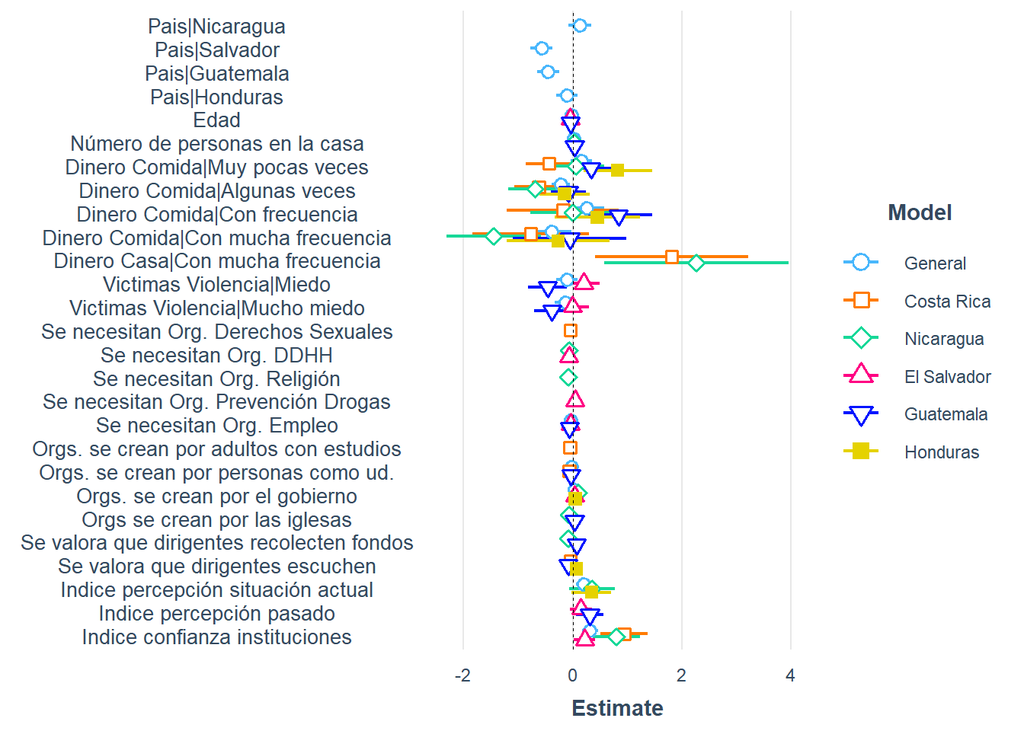

```r
plot_summs(bgen, bcr, bn, bes, bg, bh,
           model.names = c("General",
                           "Costa Rica",
                           "Nicaragua",
                           "El Salvador",
                           "Guatemala",
                           "Honduras"),
           omit.coefs = c("trabajo_remuneradoSí",
                          "dinero_comidaPocas veces",
                          "dinero_casaMuy pocas veces",
                          "dinero_casaPocas veces",
                          "dinero_casaAlgunas veces",
                          "dinero_casaCon frecuencia",
                          "dinero_busesMuy pocas veces",
                          "dinero_busesPocas veces",
                          "dinero_busesAlgunas veces",
                          "dinero_busesCon frecuencia",
                          "dinero_busesCon mucha frecuencia",
                          "victimas_violenciaPoco miedo",
                          "val_org_lideres",
                          "val_org_resuelvan",
                          "ind_aut"),

           coefs = c("Pais|Nicaragua" = "paisNicaragua",
                     "Pais|Salvador" = "paisSalvador",
                     "Pais|Guatemala" = "paisGuatemala",
                     "Pais|Honduras" = "paisHonduras",
                     "Edad" = "edad",
                     # "Trabajo remmunerado|Si" = "trabajo_remuneradoSí",
                     "Número de personas en la casa" = "personas_casa",
                     "Dinero Comida|Muy pocas veces" = "dinero_comidaMuy pocas veces",
                     # "Dinero Comida|Pocas veces" = "dinero_comidaPocas veces",
                     "Dinero Comida|Algunas veces" = "dinero_comidaAlgunas veces",
                     "Dinero Comida|Con frecuencia" = "dinero_comidaCon frecuencia",
                     "Dinero Comida|Con mucha frecuencia" = "dinero_comidaCon mucha frecuencia",
                     # "Dinero Casa|Muy pocas veces" = "dinero_casaMuy pocas veces",
                     # "Dinero Casa|Pocas veces" = "dinero_casaPocas veces",
                     # "Dinero Casa|Algunas veces" = "dinero_casaAlgunas veces",
                     # "Dinero Casa|Con frecuencia" = "dinero_casaCon frecuencia",
                     "Dinero Casa|Con mucha frecuencia" = "dinero_casaCon mucha frecuencia",
                     # "Dinero Buses|Muy pocas veces" = "dinero_busesMuy pocas veces",
                     # "Dinero Buses|Pocas veces" = "dinero_busesPocas veces",
                     # "Dinero Buses|Algunas veces" = "dinero_busesAlgunas veces",
                     # "Dinero Buses|Con frecuencia" = "dinero_busesCon frecuencia",
                     # "Dinero Buses|Con mucha frecuencia" = "dinero_busesCon mucha frecuencia",
                     # "Victimas Violencia|Poco miedo" = "victimas_violenciaPoco miedo",
                     "Victimas Violencia|Miedo" = "victimas_violenciaMiedo",
                     "Victimas Violencia|Mucho miedo" = "victimas_violenciaMucho miedo",
                     "Se necesitan Org. Derechos Sexuales" = "org_dd_sexuales",
                     "Se necesitan Org. DDHH" = "org_ddhh",
                     "Se necesitan Org. Religión" = "org_religion",
                     "Se necesitan Org. Prevención Drogas" = "org_prev_drogas",
                     "Se necesitan Org. Empleo" = "org_empleo",
                     "Orgs. se crean por adultos con estudios" = "cr_org_adultos_estudio",
                     "Orgs. se crean por personas como ud." = "cr_org_pers_ud",
                     "Orgs. se crean por el gobierno" = "cr_org_gobs",
                     "Orgs se crean por las iglesas" = "cr_org_iglesias",
                     "Se valora que dirigentes recolecten fondos" = "val_org_recolecten",
                     # "Se valora que dirigentes sean lideres democraticos" = "val_org_lideres",
                     "Se valora que dirigentes escuchen" = "val_org_escuchan",
                     # "Se valora que dirigentes resuelvan problemas" = "val_org_resuelvan",
                     "Indice percepción situación actual" = "ind_perc",
                     "Indice percepción pasado" = "ind_perc_pas",
                     "Indice confianza instituciones" = "ind_conf_inst"),
                     # "Indice autoritarismo" = "ind_aut"),
           scale = TRUE)
```